# 2R Notebook

“전 임직원 평균 급여 600만원” 철수는 매혹적인 조건의 A기업에 입사하게 되었어. 철수가 받은 첫 달 급여는 200만원이었어. 너무 속상하게도. 왜 이런일이 발생한 것일까? 철수가 놓친 부분은 무엇일까?

많은 상황들을 유추 할 수 있겠지만 쉽게 두 가지 정도로 좁혀볼 수 있을거야. 첫 째, 직급이 오를수록 급여가 많이 뛴다. 둘 째, 억대의 고액 연봉자가 있다.

너무 극단적인 예라고?

데이터는 일정한 의도를 띤 정보야. ’나의 어떠한 모습을 이러하게 보이고 싶다’라고 말이지. 예를들어 나같은 경우, 신체 중에 두꺼운 종아리가 컴플렉스야. 그래서 주로 검은색 바지를 입고 밝은 색 상의를 입는 편이야. 그래서 바지를 걷어올려보기 전까진 사람들이 나의 컴플렉스를 의아해하지. 내가 무슨 잘못을 저지는 건 아니잖아?

다시 돌아와서 우리는 이처럼 다양한 의도를 가진 데이터들이 실제로 어떤 의미를 가지는지 제대로 파악할 수 있어야 해. 숫자의 늪에서 속아 헤매지 않으려면 말야.

## 대푯값과 중심경향성

그렇다면 수 많은 변수를 포함하는 데이터를 어떻게 한눈에 파악할 수 있을까?

해당 데이터를 가장 잘 나타내는 값(대푯값)이 무엇인지 알아야 할 것이고 그 대표하는 값이 어떤 경향을 띄는지(중심경향성)를 파악한다면 큰 그림을 그릴 수 있을 거야.

이 장에서는 통계학에서 중요한 값들 평균값(mean), 중앙값(mean), 최빈값(mode) 을 배워볼 것이고 각 값들을 어떤 상황에서 적용해볼 수 있을지 살펴볼게.

## 평균값(mean)

평균값은 모두가 다 잘 알고 있듯이 ’모든 수를 더한 다음에 숫자의 전체 개수로 나눈 값’이야. 평균값은 주로 데이터가 비교적 좌우대칭이고 하나의 경향만 포함하고 있을 때 사용합니다.

```r
power.class <- c(19, 20, 20, 20, 21)
table(power.class)
```

```
power.class
19 20 21
 1  3  1
```

```r
mean(x)
```

```
[1] 20
```

## 중앙값(median)

중앙값은 이상치 때문에 데이터가 편향되어 있을 때 사용합니다.

쿵푸 교실의 예를 살펴봅시다.

```r
kungfu.class <- c(19, 19, 19, 20, 20, 20, 20, 20, 20, 21, 21, 21, 95, 97)
table(kungfu.class)
```

```
kungfu.class
19 20 21 95 97
 3  6  3  1  1
```

입력한 데이터를 그래프로 쉽게 확인해 볼 수 있습니다.

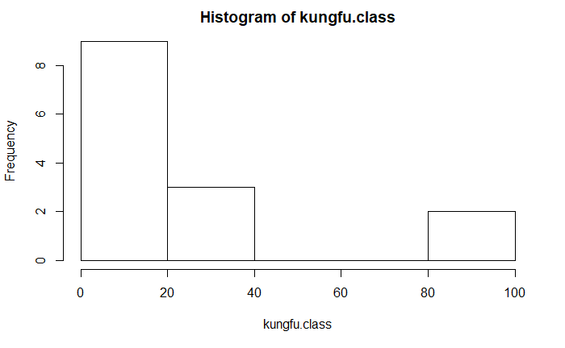

```r
hist(kungfu.class)
```

## 최빈값

최빈값(mode)은 범주적 데이터를 다룰 때나 데이터가 하나 이상의 데이터 그룹을 포함하고 있을 때 사용합니다.

범주적 데이터를 계산할 수 있는 유일한 종류의 평균은 최빈값입니다.